# Lab 1

```r
library(tidyverse)
```

1. Wylosować dziesięć liczb z rozkładów normalnych o średniej dowolnej i odchyleniu standardowym dowolnym.

```r
x <- rnorm(10, mean = 0, sd = 1)
x
```

```
 [1]  0.11651828  0.79901275 -0.03477403  0.32347510 -0.40030471 -0.19913102 -0.17979173 -0.07374903 -0.51367277 -1.05736720
```

2. Sprawdzić co oznaczają funkcje:

```r
dnorm(x, mean=0, sd=1, log = FALSE)
```

```
 [1] 0.3962433 0.2899203 0.3987011 0.3786070 0.3682252 0.3911105 0.3925462 0.3978588 0.3496340 0.2281045
```

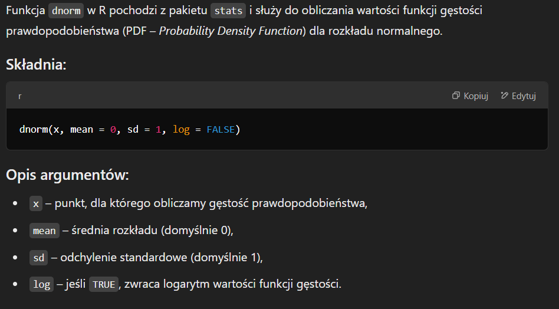

```r
pnorm(x, mean=0, sd=1, lower.tail = TRUE, log.p = FALSE)
```

```
 [1] 0.5463791 0.7878585 0.4861300 0.6268323 0.3444660 0.4210801 0.4286580 0.4706050 0.3037404 0.1451720
```

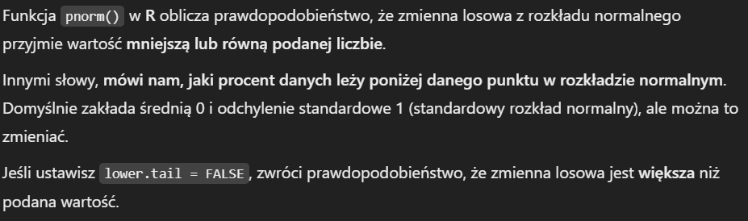

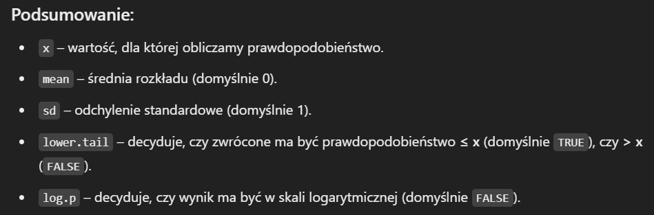

```r
p <- seq(-0.1, 1.1, by = 0.1)
qnorm(p, mean=0, sd=1, lower.tail = TRUE, log.p = FALSE)
```

```
Ostrzeżenie: wyprodukowano wartości NaN
```

```
 [1]           NaN          -Inf -1.281552e+00 -8.416212e-01 -5.244005e-01 -2.533471e-01  2.782916e-16  2.533471e-01
 [9]  5.244005e-01  8.416212e-01  1.281552e+00           Inf           NaN
```

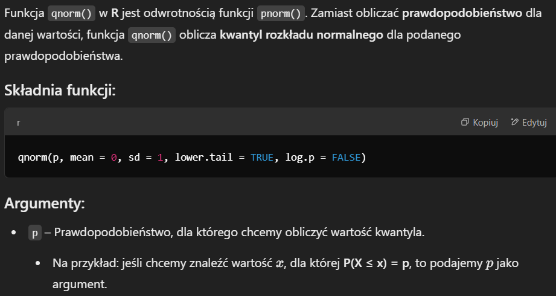

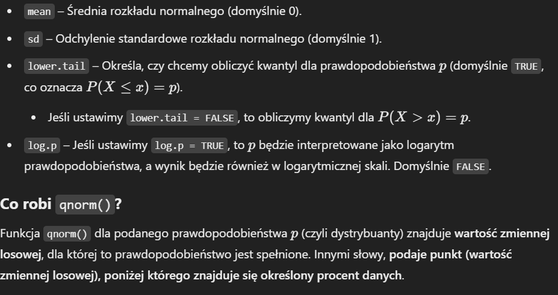

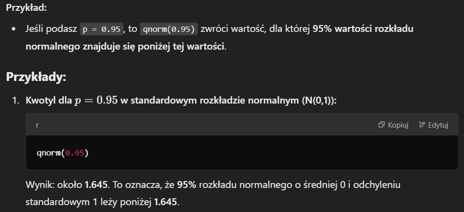

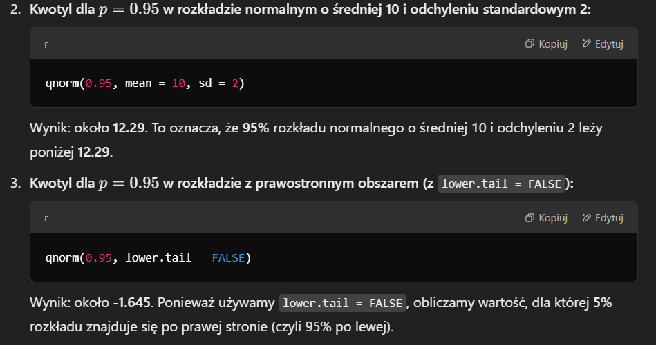

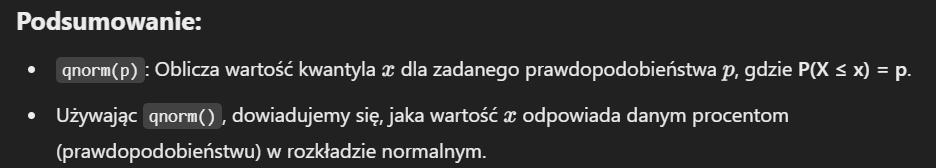

```r
rnorm(10, mean=0, sd=1)
```

```
 [1]  1.424839172 -0.145555255 -0.394478252  1.349190942 -1.112636108  0.615054790 -1.391221353 -0.008952441  1.040040489
[10]  0.202548007
```

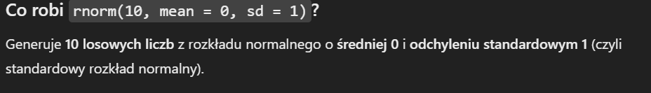

3. Wysymulować:
1. 100 zmiennych losowych o rozkładzie dwumianowym z n=10 ip=0,45.

```r
a <- rbinom(100, size = 10, prob = 0.45)
head(a, 10)
```

```
 [1] 4 4 3 7 4 7 4 8 4 5
```

2. Symuluj 1000 zmiennych losowych o rozkładzie jednostajnym z a=7 i b=10.

```r
b <- runif(1000, min = 7, max = 10)
head(b, 10)
```

```
 [1] 8.477536 8.654530 8.628668 9.677718 9.780734 9.398234 7.439045 9.739507 8.398220 8.769743
```

3. Symuluj 100 zmiennych losowych o rozkładzie Poissona z λ=3.

```r
c <- rpois(100, lambda = 3)
head(c, 10)
```

```
 [1] 4 0 4 5 4 3 3 3 3 0
```

4. Symuluj 1000 zmiennych losowych o rozkładzie normalnym z μ=544 i σ=103.

```r
d <- rnorm(1000, mean = 544, sd = 103)
head(d, 10)
```

```
 [1] 470.6104 528.4048 520.5314 530.2073 484.0155 502.8011 650.8680 554.5594 592.4738 512.1552
```

5. Symuluj 1000 zmiennych losowych o rozkładzie logarytmiczno-normalnym z μ=1,2 i σ=0,5.

```r
e <- rlnorm(1000, meanlog = 1.2, sdlog = 0.5)
head(e, 10)
```

```
 [1] 6.301224 1.309809 2.877610 4.105714 2.362813 3.031961 3.234982 3.317711 3.145587 2.736270
```

6. Sporządź wykres CDF dla powyższych rozkładów.

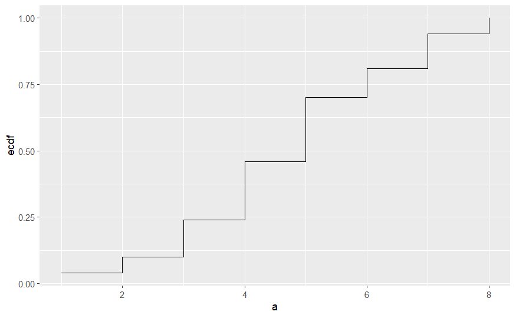

```r
dfa <- data.frame(x = a, CDF = ecdf_a(sort(a)))
dfb <- data.frame(x = b, CDF = ecdf_a(sort(a)))
dfc <- data.frame(x = c, CDF = ecdf_a(sort(a)))
dfd <- data.frame(x = d, CDF = ecdf_a(sort(a)))
dfe <- data.frame(x = e, CDF = ecdf_a(sort(a)))


ggplot(dfa, aes(a)) +
  stat_ecdf(geom = "step", pad = FALSE)
```

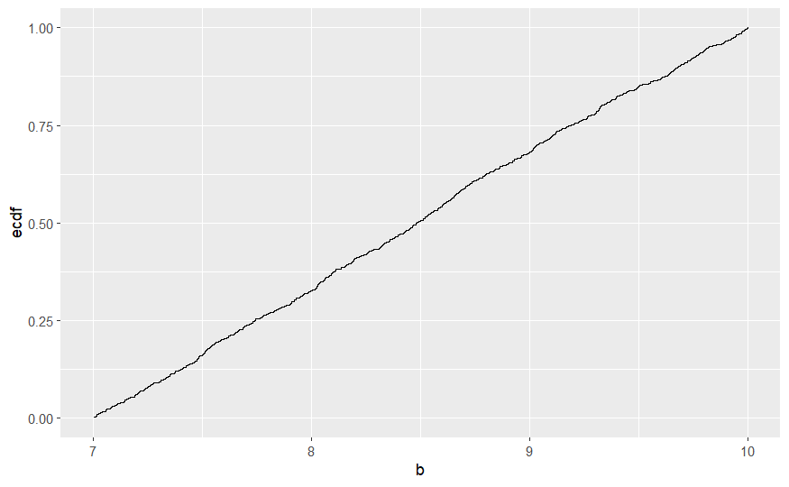

```r
ggplot(dfb, aes(b)) +
  stat_ecdf(geom = "step", pad = FALSE)
```

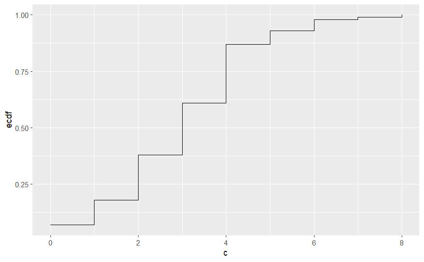

```r
ggplot(dfc, aes(c)) +
  stat_ecdf(geom = "step", pad = FALSE)
```

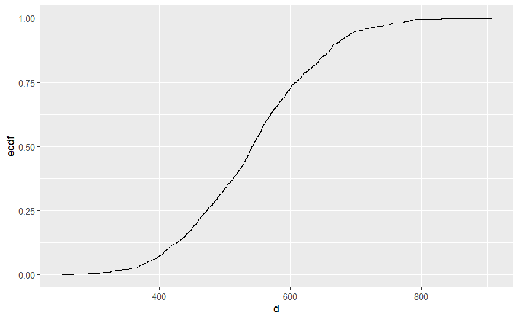

```r
ggplot(dfd, aes(d)) +
  stat_ecdf(geom = "step", pad = FALSE)
```

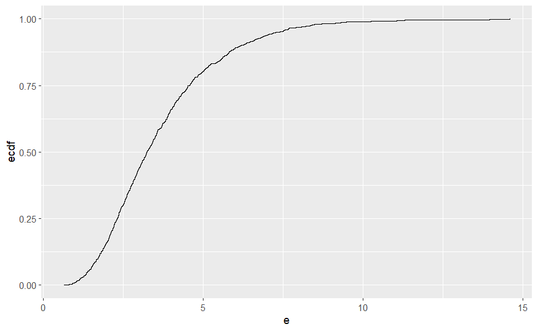

```r
ggplot(dfe, aes(e)) +
  stat_ecdf(geom = "step", pad = FALSE)
```

4. Narysować gęstość rozkładu normalnego (0,1), w przedziale [-4,4] Na tym samym wykresie narysować dystrybuantę.

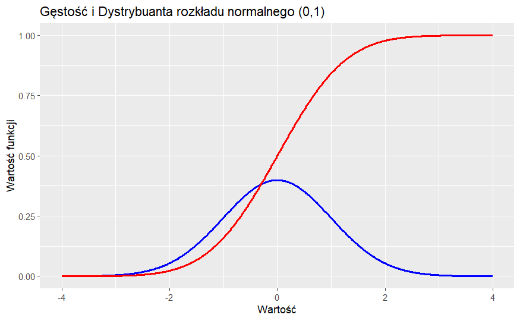

```r
x <- seq(-4, 4, by = 0.01)
y_density <- dnorm(x, mean = 0, sd = 1)  # Gęstość
y_cdf <- pnorm(x, mean = 0, sd = 1)     # Dystrybuanta

df <- data.frame(x = x, density = y_density, cdf = y_cdf)

ggplot(df) +
  geom_line(aes(x = x, y = density), color = "blue", size = 1) +
  geom_line(aes(x = x, y = cdf), color = "red", size = 1) +
  labs(title = "Gęstość i Dystrybuanta rozkładu normalnego (0,1)",
       x = "Wartość",
       y = "Wartość funkcji")
```

1. wylosować (z i bez powtórzeń) 10 wartości ze zbioru {1,2,…,20}

```r
a1 <- sample(1:20, 10, replace = TRUE)
a2 <- sample(1:20, 10, replace = FALSE)
a1
```

```
 [1]  4 14 17 11  7 12 15 10 13  7
```

```r
a2
```

```
 [1]  9 20 10  7  5 11  6 19  2 16
```

2. Stworzyć dowolny wektor i wylosować z niego kilka liczb (z powtórzeniem, bez powtórzeń)

```r
b <- c(1:10)
b1 <- sample(c, 5, replace = TRUE)
b2 <- sample(c, 5, replace = FALSE)
b1
```

```
[1] 4 1 3 5 2
```

```r
b2
```

```
[1] 3 3 1 2 4
```

3. Stworzyć macierz (5x2) z losowo wybranych (z dowolnego rozkładu jednostajnego) wartości, nazwać kolumny macierzy A, B, z takiej macierzy wylosować (z i bez powtórzeń) 3 wiersze.

```r
c <- matrix(runif(10), nrow = 5, ncol = 2)
c
```

```
          [,1]      [,2]
[1,] 0.9540912 0.3077200
[2,] 0.5854834 0.2197676
[3,] 0.4045103 0.3694889
[4,] 0.6478935 0.9842192
[5,] 0.3198206 0.1542023
```

```r
colnames(c) <- c("A", "B")
c1 <- c[sample(1:5, 3, replace = TRUE), ]
c2 <- c[sample(1:5, 3, replace = FALSE), ]
c1
```

```
             A         B
[1,] 0.3198206 0.1542023
[2,] 0.3198206 0.1542023
[3,] 0.4045103 0.3694889
```

```r
c2
```

```
             A         B
[1,] 0.5854834 0.2197676
[2,] 0.3198206 0.1542023
[3,] 0.6478935 0.9842192
```

4. Wylosuj 20 razy wartości ze zbioru: {„O”, „R”}, ze zwracaniem.

```r
d <- sample(c("O", "R"), 20, replace = TRUE)
d
```

```
 [1] "R" "R" "R" "R" "O" "R" "R" "R" "O" "R" "R" "R" "O" "R" "R" "O" "R" "O" "R" "O"
```

5. Wygeneruj 10 wartości pomiędzy 1 a 100; dodatkowo pokaż je posortowane.

```r
e <- runif(10, min = 1, max = 100)
sort(head(e, 20))
```

```
 [1] 19.19902 22.88919 27.30298 41.86187 53.83511 63.36733 67.16018 74.29310 74.91023 86.50077
```

6. Wygenerować ciąg 0 i 1, tak żeby po pojawieniu się jedynki, kolejna jedynka miała 70% szans na pojawienie się, a gdy pojawi się 0, to jedyna ma mieć 30% szans na pojawienie się.

```r
f <- numeric(50)
f[1] <- 1
for (i in 2:50) {
  if (f[i-1] == 1) {
    f[i] <- rbinom(1, 1, 0.7)
  } else {
    f[i] <- rbinom(1, 1, 0.3)
  }
}

f
```

```
 [1] 1 1 0 0 0 0 0 0 1 1 0 0 0 1 1 1 1 1 0 1 1 1 0 0 1 1 1 1 0 0 0 0 0 0 0 0 0 1 1 1 1 0 0 1 1 1 0 0 1 1
```

1. sprawdź gęstość rozkładu normalnego w zerze,

```r
dnorm(0, mean = 0, sd = 1)
```

```
[1] 0.3989423
```

2. sprawdź dystrybuantę w zerze

```r
pnorm(0, mean = 0, sd = 1)
```

```
[1] 0.5
```

3. ile masy standardowego rozkładu normalnego N(0,1) mieści się między -3 a 3?

```r
pnorm(3, mean = 0, sd = 1) - pnorm(-3, mean = 0, sd = 1)
```

```
[1] 0.9973002
```

4. wygeneruj 100 obserwacji z rozkładu N(2,1)

```r
d <- rnorm(100, mean = 2, sd = 1)
head(d, 10)
```

```
 [1] 1.65399911 0.21794293 2.46494175 0.04896939 1.48388666 2.48908032 2.90202473 2.64036299 2.95120888 1.40087679
```

5. znajdź pierwszy kwanty

```r
quantile(d, 0.25)
```

```
     25%
1.310052
```

6. narysuj histogram 1000 liczb pseudolosowych ze standardowego rozkładu normalnego

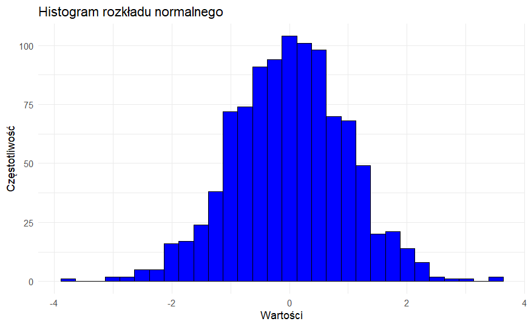

```r
e <- rnorm(1000, mean = 0, sd = 1)
df <- data.frame(x = e)

ggplot(df, aes(x = e)) +
  geom_histogram(bins = 30, fill = "blue", color = "black") +
  labs(title = "Histogram rozkładu normalnego", x = "Wartości", y = "Częstotliwość") +
  theme_minimal()
```

7. wylosuj 1000 elementową próbę z rozkładu jednostajnego i narysuj jej histogram

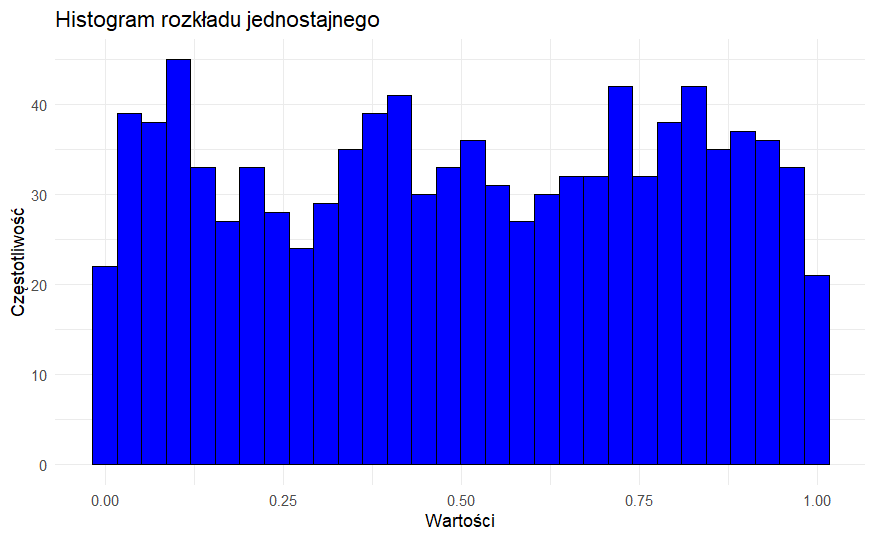

```r
f <- runif(1000, min = 0, max = 1)
df <- data.frame(x = f)


ggplot(df, aes(x = f)) +
  geom_histogram(bins = 30, fill = "blue", color = "black") +
  labs(title = "Histogram rozkładu jednostajnego", x = "Wartości", y = "Częstotliwość") +
  theme_minimal()
```

1. Wygeneruj 50 wartości z przedziału 1 do 99 zgodnie z rozkładem jednostajnym.

```r
a <- runif(50, min = 1, max = 99)
head(a, 10)
```

```
 [1] 42.805738 81.923385 27.468387 90.946087 15.650284 21.948987 89.912269 38.159730  7.298025  9.652147
```

2. Wygeneruj 5 losowych wartości z rozkładu jednostajnego.

```r
b <- runif(5)
b
```

```
[1] 0.1114088 0.1655523 0.8912224 0.8411623 0.3058511
```

3. Wygeneruj 5 losowych wartości z rozkładu jednostajnego z przedziału [5, 99].

```r
c <- runif(5, min = 5, max = 99)
c
```

```
[1] 29.24674 54.49130 67.64873 83.30875 12.75512
```

4. Wygeneruj 5 losowych, całkowitych wartości z rozkładu jednostajnego z przedziału [0,100].

```r
d <- sample(0:100, 5, replace = FALSE)
d
```

```
[1]  3 24 56 19 26
```

```r
e <- sample(0:100, 5, replace = TRUE)
e
```

```
[1] 26 83 13 48 28
```

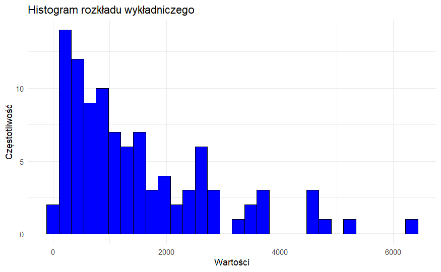

```r
a <- rexp(100, rate = 1/1500)
df <- data.frame(x = a)

ggplot(df, aes(x = a)) +
  geom_histogram(bins = 30, fill = 'blue', color = 'black') +
  labs(title = "Histogram rozkładu wykładniczego", x = "Wartości", y = "Częstotliwość") +
  theme_minimal()
```

9. Dzienna ilość kawy w litrach dozowana przez maszynę znajdującą się w holu lotniska jest zmienną losową X o ciągłym równomiernym rozkładzie przy a=7 i b=10.
1. Znajdź wartość funkcji gęstości przy x=7,6.

```r
a <- 7
b <- 10
x <- 7.6

density <- dunif(x, min = a, max = b)
density
```

```
[1] 0.3333333
```

2. Sporządź wykres prawdopodobieństwa jednostajnego rozkładu.

[figure not shown]

```r
ggplot(data.frame(x = c(a, b)), aes(x = x)) +
  geom_segment(aes(x = a, xend = b, y = density_value, yend = density_value), color = "blue") +
  geom_segment(aes(x = a, xend = a, y = 0, yend = density_value), color = "blue") +
  geom_segment(aes(x = b, xend = b, y = 0, yend = density_value), color = "blue") +
  labs(title = "Rozkład jednostajny", x = "x", y = "gęstość") +
  theme_minimal()
```

3. Znajdź prawdopodobieństwo, że w danym dniu ilość kawy dozowana przez maszynę wyniesie co najwyżej 8,8 litra.

```r
p <- punif(8.8, min = a, max = b)
p
```

```
[1] 0.6
```

4. Znajdź prawdopodobieństwo, że w danym dniu ilość kawy dozowana przez automat wyniesie co najmniej 8,5 litra.

```r
prob <- 1 - punif(8.5, min = a, max = b)
prob
```

```
[1] 0.5
```

5. Znajdź prawdopodobieństwo, że w danym dniu ilość kawy dozowana przez urządzenie będzie większa niż 7,4 litra, ale mniejsza niż 9,5 litra.

```r
p <- punif(9.5, min = a, max = b) - punif(7.4, min = a, max = b)
p
```

```
[1] 0.7
```

6. Sporządź wykres CDF.

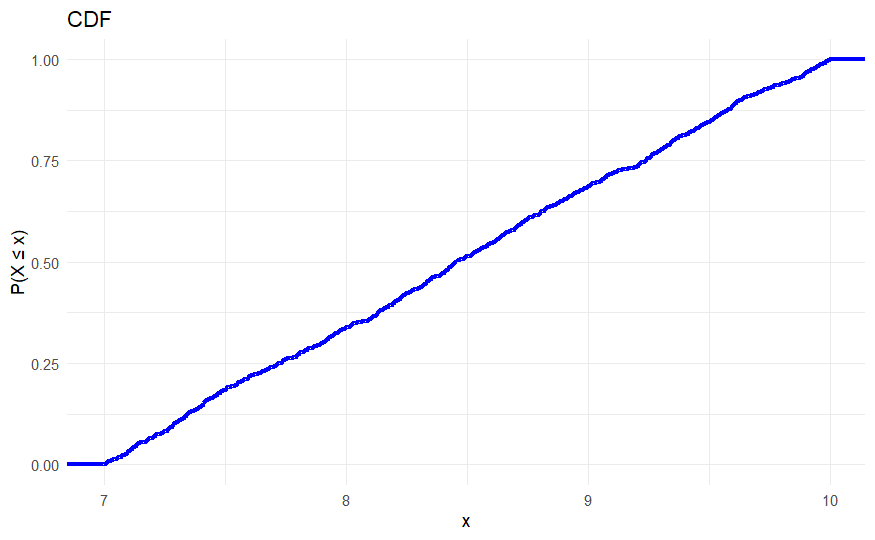

7. Jaka jest wartość c, jeśli P(X≤c)≥0,60?

```r
c <- qunif(0.6, min = a, max = b)
c
```

```
[1] 8.8
```

8. Symuluj 1000 zmiennych losowych o rozkładzie jednostajnym z a=7 i b=10

```r
head(data, 10)
```

[output not shown]

10. Stary autobus psuje się średnio 3 razy w miesiącu. (W zadaniu użyj rozkładu prawdopodobieństwa Poissona.
1. Znajdź prawdopodobieństwo, że nastąpią dokładnie 2 awarie w następnym miesiącu.

```r
p <- dpois(2, lambda = 3)
p
```

```
[1] 0.2240418
```

2. Sporządź wykres rozkładu prawdopodobieństwa Poissona.

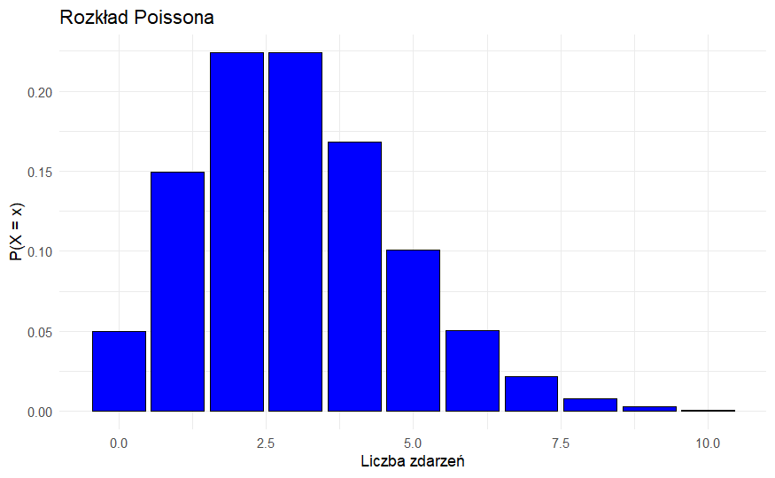

```r
x <- 0:10
y <- dpois(x, 3)
df <- data.frame(x = x, Probability = y)

# Tworzenie wykresu
ggplot(df, aes(x = x, y = Probability)) +
  geom_bar(stat = "identity", fill = "blue", color = "black") +
  labs(title = "Rozkład Poissona", x = "Liczba zdarzeń", y = "P(X = x)") +
  theme_minimal()
```

3. Jakie jest prawdopodobieństwo, że co najwyżej jedna awaria wystapi w następnym miesiącu?

```r
p <- dpois(0, 3) + dpois(1, 3)
p
```

```
[1] 0.1991483
```

4. Jakie jest prawdopodobieństwo co najmniej 3 awarii w następnym miesiącu?

```r
p <- 1 - (dpois(0, 3) + dpois(1, 3) + dpois(2, 3))
p
```

```
[1] 0.5768099
```

5. Jakie jest prawdopodobieństwo wystąpienia od 2 do 4 (włącznie) awarii w ciągu następnego miesiąca?

```r
p <- dpois(2, 3) + dpois(3, 3) + dpois(4, 3)
p
```

```
[1] 0.616115
```

6. Sporządź wykres CDF rozkładu Poissona.

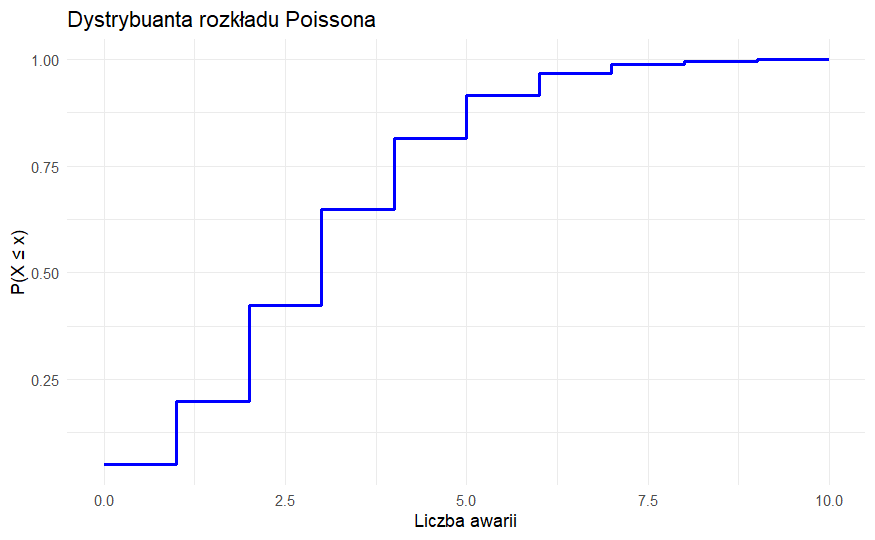

```r
cdf_vals <- ppois(x, 3)
df <- data.frame(x = x, CDF = cdf_vals)

ggplot(df, aes(x = x, y = CDF)) +
  geom_step(color = "blue", size = 1) +
  labs(title = "Dystrybuanta rozkładu Poissona", x = "Liczba awarii", y = "P(X ≤ x)") +
  theme_minimal()
```

7. Jaka jest wartość c, jeśli P(X≤c)≥0,60?

```r
c <- qpois(0.6, 3)
c
```

```
[1] 3
```

8. Symuluj 100 zmiennych losowych o rozkładzie Poissona z λ=3.

```r
data <- rpois(100, lambda = 3)
head(data, 20)
```

```
 [1] 4 0 4 3 3 3 3 5 3 8 5 0 5 2 4 2 4 2 4 1
```